# PigWeb: play, escape and inactity

Author

Liza Moscoviche & Anja Eggert

Published

April 16, 2025

# Libraries

```r
library(kableExtra)
library(tidyverse)
library(rstatix)
library(glmmTMB)
library(car)
library(DHARMa)
library(patchwork)
library(emmeans)
```

# Scripts, etc.

```r
glmmTMBcontr = glmmTMBControl(optimizer = optim,
                              optArgs   = list(method="BFGS"))
```

```r
my_theme = theme_classic() +
  theme(text = element_text(family = "sans"),
        plot.title   = element_text(face = "plain", size = 16),
        axis.title   = element_text(face = "bold", size = 16),
        axis.text    = element_text(size = 14, angle = 0, vjust = 0.5),
        legend.title = element_text(face = "bold", size = 16),
        legend.text  = element_text(face = "plain", size = 16),
        strip.text   = element_text(size = 16),
        legend.position = "top",
        panel.grid.major = element_blank(),
        panel.grid.minor = element_blank())
```

```r
set.seed(1989)
```

# Data

## Read data

```r
dat <- read_csv("./data/PigWeb-behavior.csv",
                show_col_types = FALSE)
```

## Process data

```r
dat <- dat |>
  mutate(across(where(is.character), as.factor)) |>
  mutate(date          = dmy(date),
         date.f        = as.factor(date),
         institute     = relevel(institute, ref = "AU"),
         sample        = relevel(sample,    ref = "pre"),
         context       = relevel(context,   ref = "negative"),
         space_allowance       = pen_space_m2/(group_weight_kg^0.66),
         space_allowance.log.z = as.vector(scale(log(space_allowance)))) |>
  mutate(prop_scans_inactive       = (scans_inactive/scans_activity_coded),
         # small transformation to prevent zero's in the data
         prop_scans_inactive.trans = (prop_scans_inactive*(nrow(dat)-1)+0.5)/nrow(dat))
```

# Descriptive statistics across context

Pooled for all institutes:

```r
dat |>
  group_by(context) |>
  rstatix::get_summary_stats(locomotor_play, escape_events,
                             show = c("mean","sd")) |>
  ungroup() |>
  arrange(variable) |>
  mutate(across(c(mean, sd), ~ round(., 2))) |>
  kable(caption = "Text for Fig. 4") |>
  kable_styling(bootstrap_options = c("striped", "hover"), font_size = 10) |>
  scroll_box()
```

Text for Fig. 4

| context | variable | n | mean | sd |
| --- | --- | --- | --- | --- |
| negative | locomotor_play | 128 | 0.08 | 0.32 |
| positive | locomotor_play | 120 | 1.57 | 2.10 |
| negative | escape_events | 128 | 2.82 | 4.69 |
| positive | escape_events | 120 | 0.17 | 0.58 |

# Locomotor play

## Binomial model: no interactions

Model without interactions of fixed effects and random intercepts but constant slope.

Full model:

```r
mod.locom <- glmmTMB(locomotor_play ~
                       context +
                       institute +
                       space_allowance.log.z +
                       (1|date) +
                       (1|pig_group_unique) +
                       (1|pig_id_unique),
                     data      = dat,
                     family    = "nbinom2",
                     ziformula = ~ 1,
                     control   = glmmTMBcontr)
```

Reduced model, without `context`:

```r
mod.locom.red <- glmmTMB(locomotor_play ~
                           institute +
                           space_allowance.log.z +
                           (1|date) +
                           (1|pig_group_unique) +
                           (1|pig_id_unique),
                         data      = dat,
                         family    = "nbinom2",
                         ziformula = ~ 1,
                         control   = glmmTMBcontr)
```

Comparison of reduced and full model:

```r
anova(mod.locom.red, mod.locom, test = "Chisq")
```

```
Data: dat
Models:
mod.locom.red: locomotor_play ~ institute + space_allowance.log.z + (1 | date) + , zi=~1, disp=~1
mod.locom.red:     (1 | pig_group_unique) + (1 | pig_id_unique), zi=~1, disp=~1
mod.locom: locomotor_play ~ context + institute + space_allowance.log.z + , zi=~1, disp=~1
mod.locom:     (1 | date) + (1 | pig_group_unique) + (1 | pig_id_unique), zi=~1, disp=~1
              Df    AIC    BIC  logLik deviance  Chisq Chi Df Pr(>Chisq)
mod.locom.red 10 444.30 479.43 -212.15   424.30
mod.locom     11 423.17 461.82 -200.59   401.17 23.124      1  1.519e-06 ***
---
Signif. codes:  0 '***' 0.001 '**' 0.01 '*' 0.05 '.' 0.1 ' ' 1
```

### Final model

Get effect estimates and standard errors of the model:

```r
round(summary(mod.locom)$coefficients$cond, 2)
```

```
                      Estimate Std. Error z value Pr(>|z|)
(Intercept)              -3.33       0.48   -6.95     0.00
contextpositive           2.62       0.35    7.38     0.00
instituteINRAE            1.25       0.39    3.21     0.00
instituteIRTA            -0.05       0.69   -0.07     0.94
instituteWUR              1.01       0.45    2.26     0.02
space_allowance.log.z     0.70       0.23    3.12     0.00
```

Get *p* values of fixed effects. Using `drop1()`, for factors that are part of interactions, the main effect cannot be tested. In this case `car::Anova` can be used:

```r
round(drop1(mod.locom,
            test = "Chisq"), 3)
```

```
Single term deletions

Model:
locomotor_play ~ context + institute + space_allowance.log.z +
    (1 | date) + (1 | pig_group_unique) + (1 | pig_id_unique)
                      Df    AIC    LRT Pr(>Chi)
<none>                   423.17
context                1 444.30 23.124   <2e-16 ***
institute              3 420.83  3.657    0.301
space_allowance.log.z  1 429.96  8.786    0.003 **
---
Signif. codes:  0 '***' 0.001 '**' 0.01 '*' 0.05 '.' 0.1 ' ' 1
```

```r
car::Anova(mod.locom,
           test.statistic = "Chisq",
           type = 2) # as no interaction, otherwise set type = 3
```

```
Analysis of Deviance Table (Type II Wald chisquare tests)

Response: locomotor_play
                        Chisq Df Pr(>Chisq)
context               54.5076  1  1.548e-13 ***
institute             14.4980  3   0.002300 **
space_allowance.log.z  9.7647  1   0.001779 **
---
Signif. codes:  0 '***' 0.001 '**' 0.01 '*' 0.05 '.' 0.1 ' ' 1
```

### Model diagnostics

Collinearity:

```r
xx=lm(locomotor_play ~
        context +
        institute +
        space_allowance.log.z,
      data = dat)
car::vif(xx)
```

```
                          GVIF Df GVIF^(1/(2*Df))
context               1.072961  1        1.035838
institute             1.651379  3        1.087196
space_allowance.log.z 1.712177  1        1.308502
```

Zero inflation:

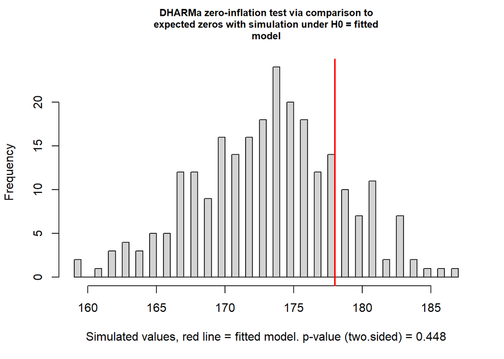

```
    DHARMa zero-inflation test via comparison to expected zeros with
    simulation under H0 = fitted model

data:  simulationOutput
ratioObsSim = 1.0264, p-value = 0.448
alternative hypothesis: two.sided
```

```r
DHARMa::testZeroInflation(mod.locom)
```

### Emmeans

```r
mod.locom.emm <- emmeans(mod.locom,
                         pairwise ~ institute,
                         data    = dat,
                         adjust  = "tukey",
                         type    = "response")

mod.locom.emm
```

```
$emmeans
 institute response     SE  df asymp.LCL asymp.UCL
 AU           0.133 0.0497 Inf    0.0640     0.277
 INRAE        0.465 0.1070 Inf    0.2954     0.731
 IRTA         0.126 0.0756 Inf    0.0391     0.408
 WUR          0.366 0.1520 Inf    0.1614     0.828

Results are averaged over the levels of: context
Confidence level used: 0.95
Intervals are back-transformed from the log scale

$contrasts
 contrast     ratio    SE  df null z.ratio p.value
 AU / INRAE   0.286 0.112 Inf    1  -3.209  0.0073
 AU / IRTA    1.053 0.729 Inf    1   0.075  0.9999
 AU / WUR     0.364 0.163 Inf    1  -2.260  0.1076
 INRAE / IRTA 3.677 2.190 Inf    1   2.188  0.1266
 INRAE / WUR  1.271 0.566 Inf    1   0.538  0.9497
 IRTA / WUR   0.346 0.281 Inf    1  -1.306  0.5593

Results are averaged over the levels of: context
P value adjustment: tukey method for comparing a family of 4 estimates
Tests are performed on the log scale
```

```r
mod.locom.emm$contrasts %>% confint()
```

```
 contrast     ratio    SE  df asymp.LCL asymp.UCL
 AU / INRAE   0.286 0.112 Inf    0.1053     0.779
 AU / IRTA    1.053 0.729 Inf    0.1781     6.229
 AU / WUR     0.364 0.163 Inf    0.1153     1.148
 INRAE / IRTA 3.677 2.190 Inf    0.7969    16.967
 INRAE / WUR  1.271 0.566 Inf    0.4049     3.989
 IRTA / WUR   0.346 0.281 Inf    0.0427     2.796

Results are averaged over the levels of: context
Confidence level used: 0.95
Conf-level adjustment: tukey method for comparing a family of 4 estimates
Intervals are back-transformed from the log scale
```

# Escape

AU had no escape behavior in either context, so should not be included in escape model.

## Binomial model: no interactions

Model without interactions of fixed effects and random intercepts but constant slope.

Full model:

```r
mod.escap <- glmmTMB(escape_events ~
                       context +
                       institute +
                       space_allowance.log.z +
                       (1|date) +
                       (1|pig_group_unique) +
                       (1|pig_id_unique),
                     data = dat |>
                       dplyr::filter(institute != "AU") |>
                       droplevels(),
                     family    = "nbinom2",
                     ziformula = ~ 1,
                     control   = glmmTMBcontr)
```

Reduced model, without `context`:

```r
mod.escap.red <- glmmTMB(escape_events ~
                           institute +
                           space_allowance.log.z +
                           (1|date) +
                           (1|pig_group_unique) +
                           (1|pig_id_unique),
                         data = dat |>
                           dplyr::filter(institute != "AU") |>
                           droplevels(),
                         family    = "nbinom2",
                         ziformula = ~ 1,
                         control   = glmmTMBcontr)
```

Comparison of reduced and full model:

```r
anova(mod.escap.red, mod.escap, test = "Chisq")
```

```
Data: droplevels(dplyr::filter(dat, institute != "AU"))
Models:
mod.escap.red: escape_events ~ institute + space_allowance.log.z + (1 | date) + , zi=~1, disp=~1
mod.escap.red:     (1 | pig_group_unique) + (1 | pig_id_unique), zi=~1, disp=~1
mod.escap: escape_events ~ context + institute + space_allowance.log.z + , zi=~1, disp=~1
mod.escap:     (1 | date) + (1 | pig_group_unique) + (1 | pig_id_unique), zi=~1, disp=~1
              Df   AIC    BIC logLik deviance  Chisq Chi Df Pr(>Chisq)
mod.escap.red  9 613.4 643.08 -297.7    595.4
mod.escap     10 545.8 578.78 -262.9    525.8 69.602      1  < 2.2e-16 ***
---
Signif. codes:  0 '***' 0.001 '**' 0.01 '*' 0.05 '.' 0.1 ' ' 1
```

### Final model

Get effect estimates and standard errors of the model:

```r
round(summary(mod.escap)$coefficients$cond, 2)
```

```
                      Estimate Std. Error z value Pr(>|z|)
(Intercept)               1.61       0.48    3.35     0.00
contextpositive          -3.48       0.47   -7.41     0.00
instituteIRTA            -1.17       1.01   -1.16     0.25
instituteWUR             -1.74       0.76   -2.28     0.02
space_allowance.log.z    -0.97       0.47   -2.06     0.04
```

Get *p* values of fixed effects. Using `drop1()`, for factors that are part of interactions, the main effect cannot be tested. In this case `car::Anova` can be used:

```r
round(drop1(mod.escap,
            test = "Chisq"), 3)
```

```
Single term deletions

Model:
escape_events ~ context + institute + space_allowance.log.z +
    (1 | date) + (1 | pig_group_unique) + (1 | pig_id_unique)
                      Df    AIC    LRT Pr(>Chi)
<none>                   545.80
context                1 613.40 69.602   <2e-16 ***
institute              2 547.61  5.818    0.055 .
space_allowance.log.z  1 548.66  4.860    0.027 *
---
Signif. codes:  0 '***' 0.001 '**' 0.01 '*' 0.05 '.' 0.1 ' ' 1
```

```r
car::Anova(mod.escap,
           test.statistic = "Chisq",
           type = 2) # as no interaction, otherwise set type = 3
```

```
Analysis of Deviance Table (Type II Wald chisquare tests)

Response: escape_events
                        Chisq Df Pr(>Chisq)
context               54.9714  1  1.223e-13 ***
institute              5.8160  2    0.05459 .
space_allowance.log.z  4.2456  1    0.03935 *
---
Signif. codes:  0 '***' 0.001 '**' 0.01 '*' 0.05 '.' 0.1 ' ' 1
```

### Model diagnostics

Collinearity:

```r
xx=lm(escape_events ~
        context +
        institute +
        space_allowance.log.z,
      data = dat)
car::vif(xx)
```

```
                          GVIF Df GVIF^(1/(2*Df))
context               1.072961  1        1.035838
institute             1.651379  3        1.087196
space_allowance.log.z 1.712177  1        1.308502
```

Zero inflation:

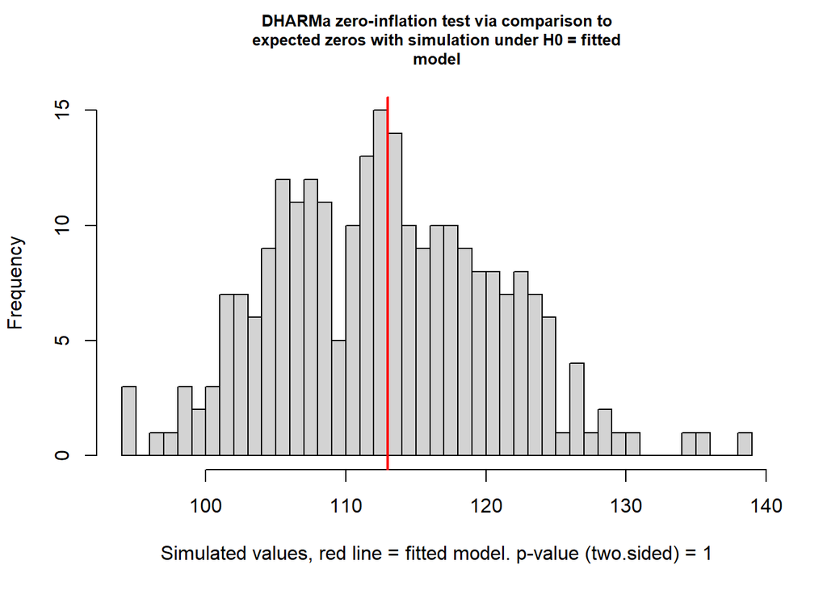

```
    DHARMa zero-inflation test via comparison to expected zeros with
    simulation under H0 = fitted model

data:  simulationOutput
ratioObsSim = 0.99739, p-value = 1
alternative hypothesis: two.sided
```

```r
DHARMa::testZeroInflation(mod.escap)
```

### Emmeans

```r
mod.escap.emm <- emmeans(mod.escap,
                         pairwise ~ institute,
                         data    = dat,
                         adjust  = "tukey",
                         type    = "response")

mod.escap.emm

mod.escap.emm$contrasts %>% confint()
```

[output not shown]

# Inactivity

## Binomial model: no interactions

Model without interactions of fixed effects and random intercepts but constant slope.

Full model:

```r
mod.inact <- glmmTMB(prop_scans_inactive.trans ~
                       context +
                       institute +
                       space_allowance.log.z +
                       offset(log(scans_activity_coded)) +
                       (1|date) +
                       (1|pig_group_unique) +
                       (1|pig_id_unique),
                     data      = dat,
                     family    = beta_family(link="logit"),
                     ziformula = ~ 1,
                     control   = glmmTMBcontr)
```

Reduced model, without `context` and `institute`:

```r
mod.inact.red <- glmmTMB(prop_scans_inactive.trans ~
                           space_allowance.log.z +
                           offset(log(scans_activity_coded)) +
                           (1|date) +
                           (1|pig_group_unique) +
                           (1|pig_id_unique),
                         data      = dat,
                         family    = beta_family(link="logit"),
                         ziformula = ~ 1,
                         control   = glmmTMBcontr)
```

Comparison of reduced and full model:

```r
anova(mod.inact.red, mod.inact, test = "Chisq")
```

```
Data: dat
Models:
mod.inact.red: prop_scans_inactive.trans ~ space_allowance.log.z + offset(log(scans_activity_coded)) + , zi=~1, disp=~1
mod.inact.red:     (1 | date) + (1 | pig_group_unique) + (1 | pig_id_unique), zi=~1, disp=~1
mod.inact: prop_scans_inactive.trans ~ context + institute + space_allowance.log.z + , zi=~1, disp=~1
mod.inact:     offset(log(scans_activity_coded)) + (1 | date) + (1 | pig_group_unique) + , zi=~1, disp=~1
mod.inact:     (1 | pig_id_unique), zi=~1, disp=~1
              Df     AIC     BIC logLik deviance  Chisq Chi Df Pr(>Chisq)
mod.inact.red  7 -945.25 -920.68 479.62  -959.25
mod.inact     11 -950.85 -912.25 486.43  -972.85 13.607      4   0.008662 **
---
Signif. codes:  0 '***' 0.001 '**' 0.01 '*' 0.05 '.' 0.1 ' ' 1
```

### Final model

Get effect estimates and standard errors of the model:

```r
round(summary(mod.inact)$coefficients$cond, 2)
```

```
                      Estimate Std. Error z value Pr(>|z|)
(Intercept)              -3.06       0.31   -9.83     0.00
contextpositive          -0.30       0.23   -1.28     0.20
instituteINRAE           -0.70       0.41   -1.74     0.08
instituteIRTA            -1.62       0.54   -3.00     0.00
instituteWUR             -1.46       0.37   -3.89     0.00
space_allowance.log.z     0.05       0.16    0.31     0.76
```

Get *p* values of fixed effects. Using `drop1()`, for factors that are part of interactions, the main effect cannot be tested. In this case `car::Anova` can be used:

```r
round(drop1(mod.inact,
            test = "Chisq"), 3)
```

```
Single term deletions

Model:
prop_scans_inactive.trans ~ context + institute + space_allowance.log.z +
    offset(log(scans_activity_coded)) + (1 | date) + (1 | pig_group_unique) +
    (1 | pig_id_unique)
                      Df     AIC    LRT Pr(>Chi)
<none>                   -950.85
context                1 -951.33  1.527    0.217
institute              3 -943.60 13.252    0.004 **
space_allowance.log.z  1 -952.76  0.095    0.758
---
Signif. codes:  0 '***' 0.001 '**' 0.01 '*' 0.05 '.' 0.1 ' ' 1
```

```r
car::Anova(mod.inact,
           test.statistic = "Chisq",
           type = 2) # as no interaction, otherwise set type = 3
```

```
Analysis of Deviance Table (Type II Wald chisquare tests)

Response: prop_scans_inactive.trans
                        Chisq Df Pr(>Chisq)
context                1.6334  1  0.2012321
institute             17.7004  3  0.0005071 ***
space_allowance.log.z  0.0958  1  0.7569653
---
Signif. codes:  0 '***' 0.001 '**' 0.01 '*' 0.05 '.' 0.1 ' ' 1
```

### Model diagnostics

Collinearity:

```r
xx=lm(prop_scans_inactive.trans ~
        context +
        institute +
        space_allowance.log.z,
      data = dat)
car::vif(xx)
```

```
                          GVIF Df GVIF^(1/(2*Df))
context               1.075417  1        1.037023
institute             1.656865  3        1.087797
space_allowance.log.z 1.720051  1        1.311507
```

Zero inflation:

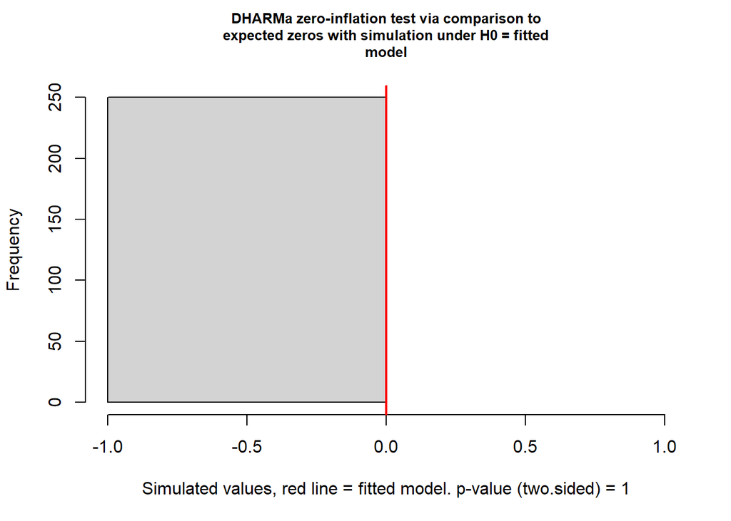

```
    DHARMa zero-inflation test via comparison to expected zeros with
    simulation under H0 = fitted model

data:  simulationOutput
ratioObsSim = NaN, p-value = 1
alternative hypothesis: two.sided
```

```r
DHARMa::testZeroInflation(mod.inact)
```

### Emmeans

```r
mod.inact.emm <- emmeans(mod.inact,
                         pairwise ~ institute,
                         data    = dat,
                         adjust  = "tukey",
                         type    = "response")

mod.inact.emm
```

```
$emmeans
 institute response     SE  df asymp.LCL asymp.UCL
 AU          0.2934 0.0619 Inf    0.1878     0.427
 INRAE       0.1704 0.0403 Inf    0.1050     0.264
 IRTA        0.0760 0.0298 Inf    0.0346     0.159
 WUR         0.0882 0.0194 Inf    0.0568     0.134

Results are averaged over the levels of: context
Confidence level used: 0.95
Intervals are back-transformed from the logit scale

$contrasts
 contrast     odds.ratio    SE  df null z.ratio p.value
 AU / INRAE         2.02 0.820 Inf    1   1.735  0.3053
 AU / IRTA          5.05 2.720 Inf    1   3.005  0.0141
 AU / WUR           4.29 1.610 Inf    1   3.894  0.0006
 INRAE / IRTA       2.50 1.260 Inf    1   1.820  0.2638
 INRAE / WUR        2.12 0.745 Inf    1   2.145  0.1391
 IRTA / WUR         0.85 0.405 Inf    1  -0.341  0.9864

Results are averaged over the levels of: context
P value adjustment: tukey method for comparing a family of 4 estimates
Tests are performed on the log odds ratio scale
```

```r
mod.inact.emm$contrasts %>% confint()
```

```
 contrast     odds.ratio    SE  df asymp.LCL asymp.UCL
 AU / INRAE         2.02 0.820 Inf     0.713      5.73
 AU / IRTA          5.05 2.720 Inf     1.265     20.16
 AU / WUR           4.29 1.610 Inf     1.642     11.22
 INRAE / IRTA       2.50 1.260 Inf     0.686      9.09
 INRAE / WUR        2.12 0.745 Inf     0.862      5.23
 IRTA / WUR         0.85 0.405 Inf     0.250      2.89

Results are averaged over the levels of: context
Confidence level used: 0.95
Conf-level adjustment: tukey method for comparing a family of 4 estimates
Intervals are back-transformed from the log odds ratio scale
```

# Figures

## Figure 4: Locomotor play all institutes

There are 8 NA’s in the data:

```r
summary(dat$locomotor_play)
```

```
   Min. 1st Qu.  Median    Mean 3rd Qu.    Max.    NA's
 0.0000  0.0000  0.0000  0.7984  1.0000  7.0000       8
```

```r
plot.locom <- dat |>
  mutate(context.jit = jitter(as.numeric(context), 0.3)) |>
  mutate(locomotor_play.jit = jitter(as.numeric(locomotor_play), 0.3)) |>

  ggplot(aes(y = locomotor_play.jit)) +
  geom_boxplot(aes(x = context),
               col = "black", fill = NA,
               outlier.shape = NA, width=0.5,
               position = position_dodge(0.5)) +
  geom_line(aes(x = context.jit, group = pig_id_unique),
            col = "grey80", linewidth = 0.2) +
  geom_point(aes(x = context.jit,
                 col = institute,
                 shape = institute),
             size = 3, alpha = 0.7) +
  scale_colour_manual(values = c("#481568FF", "#32648EFF", "#94D840FF", "#FDE725FF")) +
  scale_shape_manual(values = c(17, 15, 16, 18)) +
  scale_y_continuous(limits=c(-0.1, 7.1),
                     breaks = seq(0,7,1)) +
  labs(x   = "Context",
       y   = "Locomotor play (counts)",
       # Matching title ensures a single legend
       col = "Institutes",
       shape = "Institutes") +
  my_theme
```

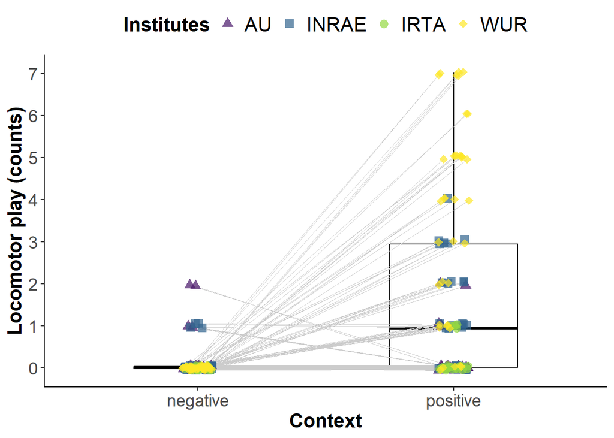

```r
plot.locom
```

```r
png("./plots/locom-play-context.png",
    width = 150, height = 180, units = "mm",
    pointsize = 10, res = 600)

plot.locom

dev.off()
```

## Figure 5: Escape events all institutes

There are 8 NA’s in the data:

```r
summary(dat$escape_events)
```

```
   Min. 1st Qu.  Median    Mean 3rd Qu.    Max.    NA's
  0.000   0.000   0.000   1.536   1.000  30.000       8
```

```r
plot.escap <- dat |>
  mutate(context.jit = jitter(as.numeric(context), 0.3)) |>
  mutate(escape_events.jit = jitter(as.numeric(escape_events), 0.3)) |>

  ggplot(aes(y = escape_events.jit)) +
  geom_boxplot(aes(x = context),
               col = "black", fill = NA,
               outlier.shape = NA, width=0.5,
               position = position_dodge(0.5)) +
  geom_line(aes(x = context.jit, group = pig_id_unique),
            col = "grey80", linewidth = 0.2) +
  geom_point(aes(x = context.jit,
                 col = institute,
                 shape = institute),
             size = 3, alpha = 0.7) +
  scale_colour_manual(values = c("#481568FF", "#32648EFF", "#94D840FF", "#FDE725FF")) +
  scale_shape_manual(values = c(17, 15, 16, 18)) +
  scale_y_continuous(limits=c(-0.1, 30.1),
                     breaks = seq(0,30,5)) +
  labs(x   = "Context",
       y   = "Escape events (counts)",
       # Matching title ensures a single legend
       col = "Institutes",
       shape = "Institutes") +
  my_theme
```

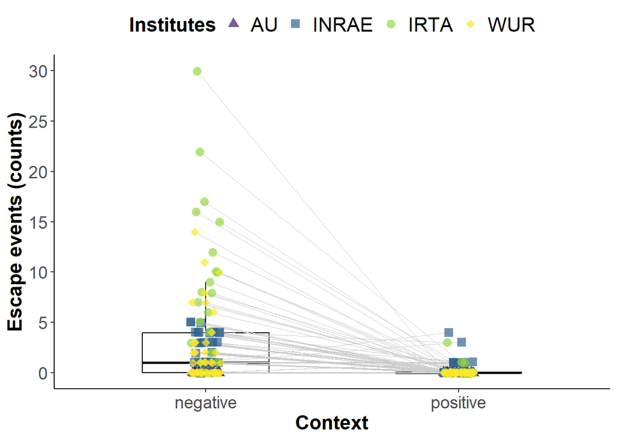

```r
plot.escap
```

```r
png("./plots/escape-context.png",
    width = 150, height = 180, units = "mm",
    pointsize = 10, res = 600)

plot.escap

dev.off()
```

## Figure 4+5 combined: (A) Locomotor play and (B) escape events

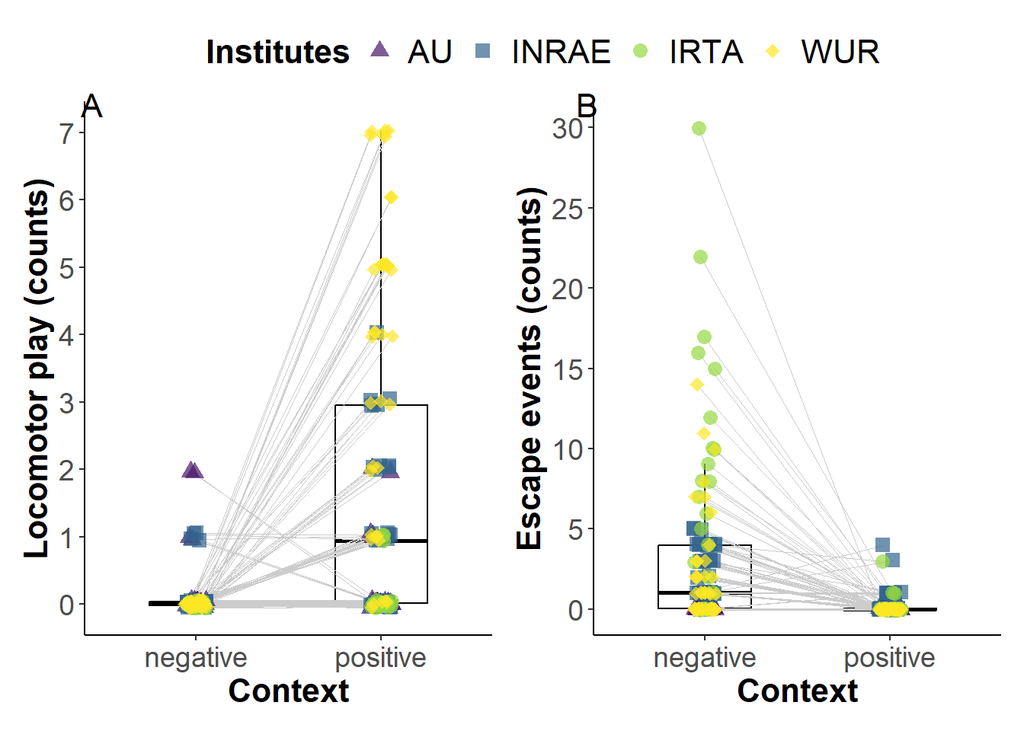

```r
combined <- plot.locom + plot.escap &
  theme(legend.position = "top")

combined +
  plot_layout(guides = "collect") +
  plot_annotation(tag_levels = 'A') &
  theme(plot.tag = element_text(size = 16),
        plot.tag.position = c(.15, .88))
```

```r
png("./plots/locom-escape-context.png",
    width = 300, height = 180, units = "mm",
    pointsize = 10, res = 600)

combined +
  plot_layout(guides = "collect") +
  plot_annotation(tag_levels = 'A') &
  theme(plot.tag = element_text(size = 16),
        plot.tag.position = c(.15, .88))

dev.off()
```

# Citing R

“All analyses were performed using R Statistical Software (version 4.4.2; R Core Team 2024)”.

Reference: R Core Team (2024). R: A language and environment for statistical computing. R Foundation for Statistical Computing, Vienna, Austria. URL https://www.R-project.org/.

```r
citation()
```

```
  R Core Team (2024). _R: A Language and Environment for Statistical
  Computing_. R Foundation for Statistical Computing, Vienna, Austria.
  <https://www.R-project.org/>.

Ein BibTeX-Eintrag für LaTeX-Benutzer ist

  @Manual{,
    title = {R: A Language and Environment for Statistical Computing},
    author = {{R Core Team}},
    organization = {R Foundation for Statistical Computing},
    address = {Vienna, Austria},
    year = {2024},
    url = {https://www.R-project.org/},
  }

We have invested a lot of time and effort in creating R, please cite it
when using it for data analysis. See also 'citation("pkgname")' for
citing R packages.
```

```r
version$version.string
```

```
[1] "R version 4.4.2 (2024-10-31 ucrt)"
```

```r
citation("kableExtra")
```

```
Um Paket 'kableExtra' in Publikationen zu zitieren, nutzen Sie bitte:

  Zhu H (2024). _kableExtra: Construct Complex Table with 'kable' and
  Pipe Syntax_. R package version 1.4.0,
  <https://CRAN.R-project.org/package=kableExtra>.

Ein BibTeX-Eintrag für LaTeX-Benutzer ist

  @Manual{,
    title = {kableExtra: Construct Complex Table with 'kable' and Pipe Syntax},
    author = {Hao Zhu},
    year = {2024},
    note = {R package version 1.4.0},
    url = {https://CRAN.R-project.org/package=kableExtra},
  }
```

```r
citation("tidyverse")
```

```
Um Paket 'tidyverse' in Publikationen zu zitieren, nutzen Sie bitte:

  Wickham H, Averick M, Bryan J, Chang W, McGowan LD, François R,
  Grolemund G, Hayes A, Henry L, Hester J, Kuhn M, Pedersen TL, Miller
  E, Bache SM, Müller K, Ooms J, Robinson D, Seidel DP, Spinu V,
  Takahashi K, Vaughan D, Wilke C, Woo K, Yutani H (2019). "Welcome to
  the tidyverse." _Journal of Open Source Software_, *4*(43), 1686.
  doi:10.21105/joss.01686 <https://doi.org/10.21105/joss.01686>.

Ein BibTeX-Eintrag für LaTeX-Benutzer ist

  @Article{,
    title = {Welcome to the {tidyverse}},
    author = {Hadley Wickham and Mara Averick and Jennifer Bryan and Winston Chang and Lucy D'Agostino McGowan and Romain François and Garrett Grolemund and Alex Hayes and Lionel Henry and Jim Hester and Max Kuhn and Thomas Lin Pedersen and Evan Miller and Stephan Milton Bache and Kirill Müller and …
    year = {2019},
    journal = {Journal of Open Source Software},
    volume = {4},
    number = {43},
    pages = {1686},
    doi = {10.21105/joss.01686},
  }
```

```r
citation("rstatix")
```

```
Um Paket 'rstatix' in Publikationen zu zitieren, nutzen Sie bitte:

  Kassambara A (2023). _rstatix: Pipe-Friendly Framework for Basic
  Statistical Tests_. R package version 0.7.2,
  <https://CRAN.R-project.org/package=rstatix>.

Ein BibTeX-Eintrag für LaTeX-Benutzer ist

  @Manual{,
    title = {rstatix: Pipe-Friendly Framework for Basic Statistical Tests},
    author = {Alboukadel Kassambara},
    year = {2023},
    note = {R package version 0.7.2},
    url = {https://CRAN.R-project.org/package=rstatix},
  }
```

```r
citation("glmmTMB")
```

```
  Mollie E. Brooks, Kasper Kristensen, Koen J. van Benthem, Arni
  Magnusson, Casper W. Berg, Anders Nielsen, Hans J. Skaug, Martin
  Maechler and Benjamin M. Bolker (2017). glmmTMB Balances Speed and
  Flexibility Among Packages for Zero-inflated Generalized Linear Mixed
  Modeling. The R Journal, 9(2), 378-400. doi: 10.32614/RJ-2017-066.

Ein BibTeX-Eintrag für LaTeX-Benutzer ist

  @Article{,
    author = {Mollie E. Brooks and Kasper Kristensen and Koen J. {van Benthem} and Arni Magnusson and Casper W. Berg and Anders Nielsen and Hans J. Skaug and Martin Maechler and Benjamin M. Bolker},
    title = {{glmmTMB} Balances Speed and Flexibility Among Packages for Zero-inflated Generalized Linear Mixed Modeling},
    year = {2017},
    journal = {The R Journal},
    doi = {10.32614/RJ-2017-066},
    pages = {378--400},
    volume = {9},
    number = {2},
  }
```

```r
citation("car")
```

```
  Fox J, Weisberg S (2019). _An R Companion to Applied Regression_,
  Third edition. Sage, Thousand Oaks CA.
  <https://www.john-fox.ca/Companion/>.

Ein BibTeX-Eintrag für LaTeX-Benutzer ist

  @Book{,
    title = {An {R} Companion to Applied Regression},
    edition = {Third},
    author = {John Fox and Sanford Weisberg},
    year = {2019},
    publisher = {Sage},
    address = {Thousand Oaks {CA}},
    url = {https://www.john-fox.ca/Companion/},
  }
```

```r
citation("DHARMa")
```

```
Um Paket 'DHARMa' in Publikationen zu zitieren, nutzen Sie bitte:

  Hartig F (2024). _DHARMa: Residual Diagnostics for Hierarchical
  (Multi-Level / Mixed) Regression Models_. R package version 0.4.7,
  <https://CRAN.R-project.org/package=DHARMa>.

Ein BibTeX-Eintrag für LaTeX-Benutzer ist

  @Manual{,
    title = {DHARMa: Residual Diagnostics for Hierarchical (Multi-Level / Mixed)
Regression Models},
    author = {Florian Hartig},
    year = {2024},
    note = {R package version 0.4.7},
    url = {https://CRAN.R-project.org/package=DHARMa},
  }
```

```r
citation("patchwork")
```

```
Um Paket 'patchwork' in Publikationen zu zitieren, nutzen Sie bitte:

  Pedersen T (2024). _patchwork: The Composer of Plots_. R package
  version 1.3.0, <https://CRAN.R-project.org/package=patchwork>.

Ein BibTeX-Eintrag für LaTeX-Benutzer ist

  @Manual{,
    title = {patchwork: The Composer of Plots},
    author = {Thomas Lin Pedersen},
    year = {2024},
    note = {R package version 1.3.0},
    url = {https://CRAN.R-project.org/package=patchwork},
  }
```